# cytokit examples

2018-04-02

Load the package

```r
library(cytokit)
```

# Basic visualizations

## t-SNE/PCA

Basic t-SNE of a dataset (like `Seurat::TSNEPlot()`):

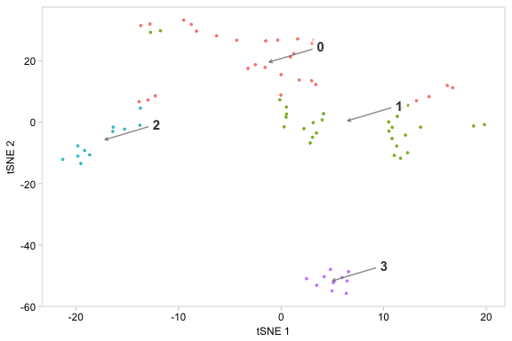

```r
tsne(pbmc)
```

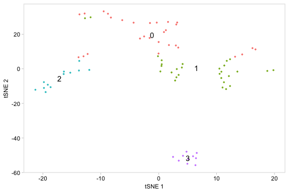

```r
tsne(pbmc, label_repel = FALSE)
```

Colour the cells by a column in `seurat@meta.data` containing a continuous variable, e.g. the number of UMIs:

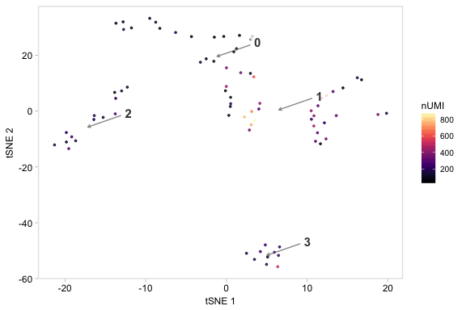

```r
tsne(pbmc, colour_by = "nUMI", colour_by_type = "continuous", colours = viridis::magma(100))
```

Colour the cells by a column in `seurat@meta.data` containing a discrete variable, e.g. here, the resolution 1.0 cluster assignments:

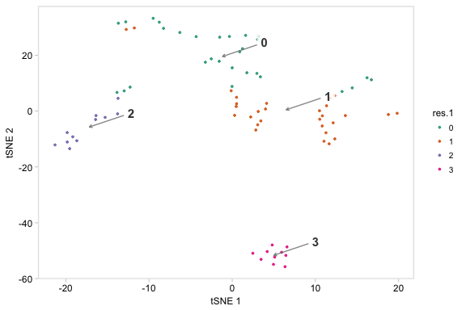

```r
tsne(pbmc, colour_by = "res.1", colour_by_type = "discrete",
     # Getting some colours from a Color Brewer palette
     colours = RColorBrewer::brewer.pal(length(unique(pbmc@meta.data$res.1)), "Dark2"))
```

## Highlight cluster in t-SNE space

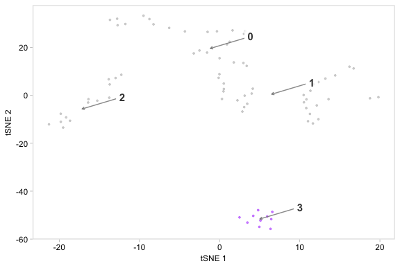

```r
# Highlight cluster 3 on the tSNE plot
highlight(pbmc, 3)
```

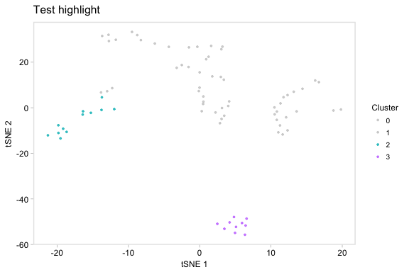

```r
# Pass additional arguments to cytokit::tsne
highlight(pbmc, c(2, 3), label = FALSE, title = "Test highlight")
```

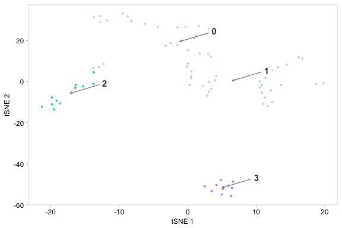

```r
# Change default colour
highlight(pbmc, c(2, 3), default_colour = "lightblue")
```

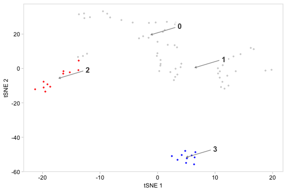

```r
# Specify the colours to highlight the clusters with
highlight(pbmc, c(2, 3), c("red", "blue"))
```

# Computed visualizations

Plot a t-SNE coloured by mean marker expression

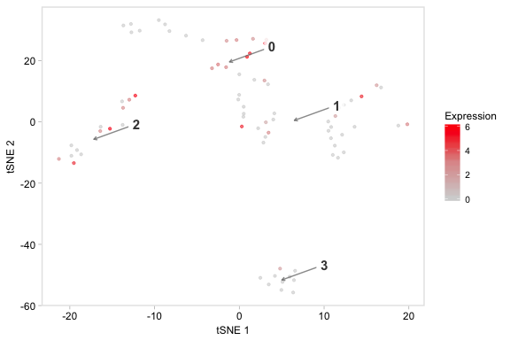

```r
tsneByMeanMarkerExpression(pbmc, c("IL32", "CD2"))
```

Plot a t-SNE coloured by percentiles marker expression

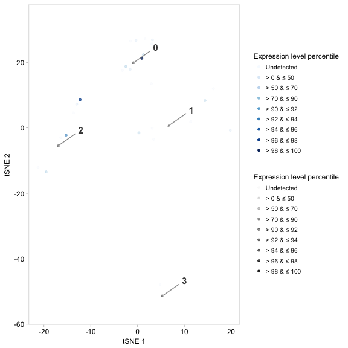

```r
tsneByPercentileMarkerExpression(pbmc, c("IL32", "CD2"))
```

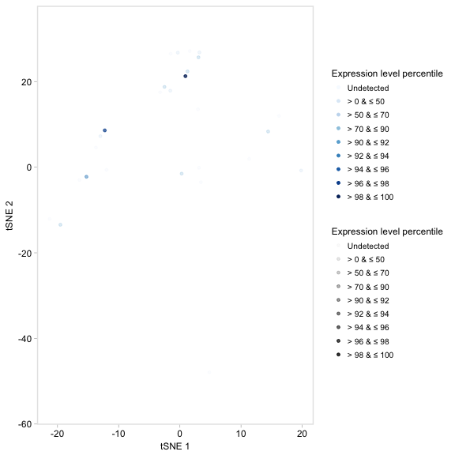

```r
# No labels
tsneByPercentileMarkerExpression(pbmc, c("IL32", "CD2"), label = FALSE)
```

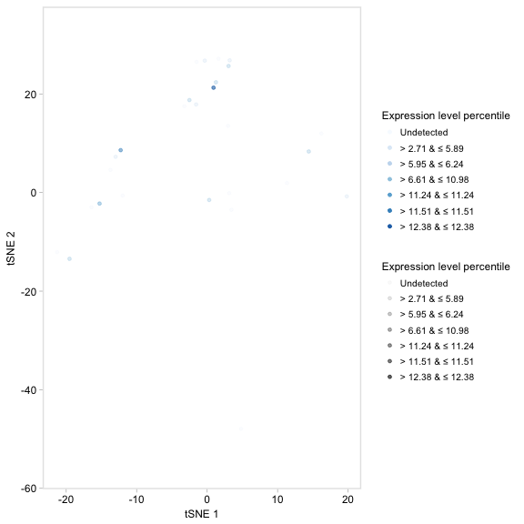

```r
# Use values in legend instead
tsneByPercentileMarkerExpression(pbmc, c("IL32", "CD2"), label = FALSE,
                                 legend_options = "values")
```

Dashboard plot, which gives a bit more distributional information than tSNE:

```r
tsneByPercentileMarkerExpression(pbmc, c("IL32", "CD2"), label = TRUE, extra = TRUE, verbose = TRUE)
```

```
#> Computing percentiles...
#> Constructing percentiles plot...
#> Computing frequencies...
#> Constructing bar plot...
#> Computing means...
#> Constructing ridge plot...
#> Combining plots...
```

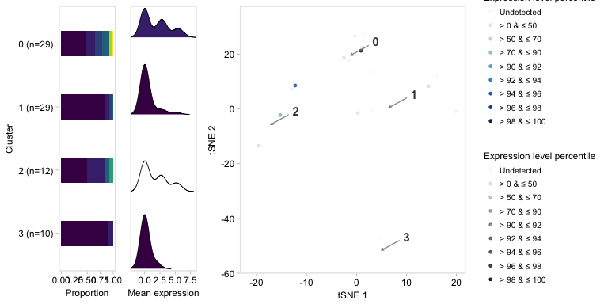

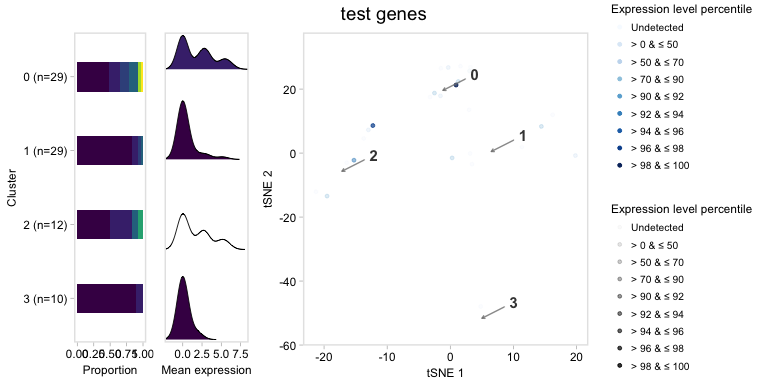

```r
# This function is a shortcut for the above
dashboard(pbmc, c("IL32", "CD2"), title = "test genes")
```

Notes:

- This doesn’t look good with few clusters; for a real sample with ~ 15 clusters, a good set of dimensions is width = 14, height = 8
- Known issue: the dashboard plots throw a big warning related to the unicode symbols. Do warning = FALSE in the chunk options to not print it.

Feature plot, akin to `Seurat::FeaturePlot()`

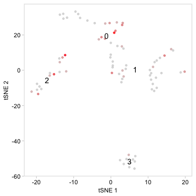

```r
tsneByPercentileMarkerExpression(pbmc, c("IL32", "CD2"), label_repel = FALSE, palette = "redgrey", alpha = FALSE, point_size = 1, legend = FALSE)
```

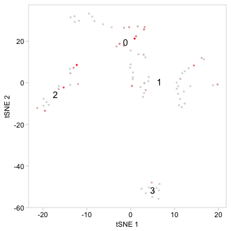

```r
# This function is a shortcut for the above, except by default it makes one plot
# per gene (set per_gene = FALSE like below to have one plot with the summary statistic)
feature(pbmc, c("IL32", "CD2"), per_gene = FALSE)
```

Feature plots for individual genes:

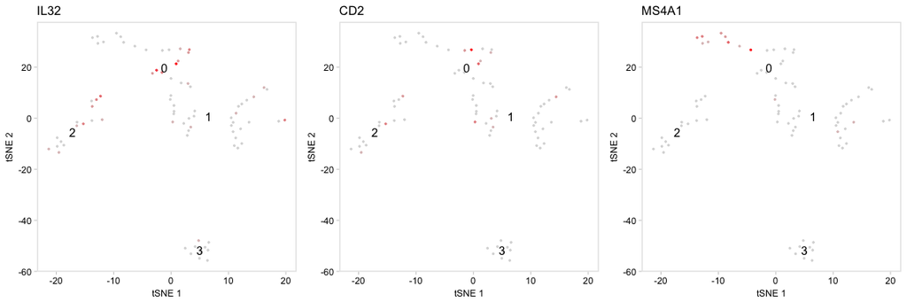

```r
feature(pbmc, c("IL32", "CD2", "MS4A1"), per_gene = TRUE)
```

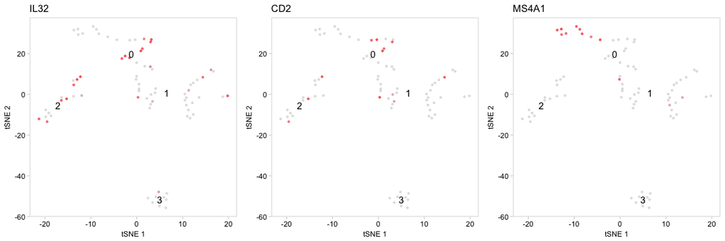

```r
feature(pbmc, c("IL32", "CD2", "MS4A1"), per_gene = TRUE, statistic = "mean")
```

## Violins

Violin plot for a set of genes (like `Seurat::VlnPlot()`)

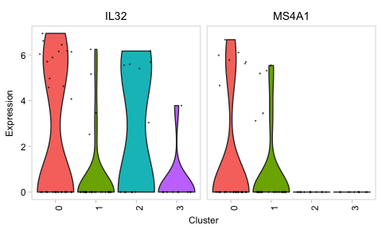

```r
vln(pbmc, c("IL32", "MS4A1"), facet_by = "gene")
```

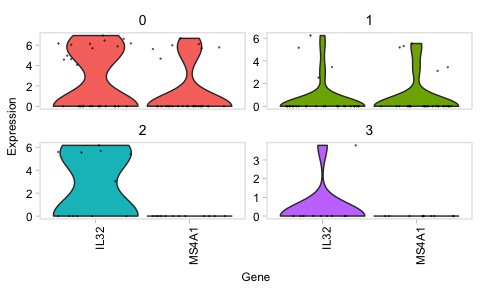

```r
# Inverted, one plot per cluster (the default)
vln(pbmc, c("IL32", "MS4A1"), facet_by = "cluster")
```

## Violin grid

Panel of tiny violin plots for a set of genes, as in Figure 5D in the drop-seq paper. See docs for default ordering method.

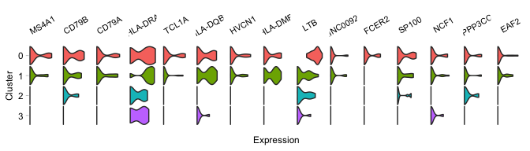

```r
# Use the first 15 genes in the data
vlnGrid(pbmc, genes = head(rownames(pbmc@data), 15))
```

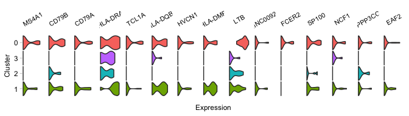

```r
# Specify order
vlnGrid(pbmc, head(rownames(pbmc@data), 15), order = c(0, 3, 2, 1))
```

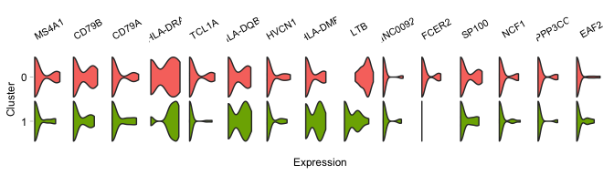

```r
# Plot a subset of clusters
vlnGrid(pbmc, head(rownames(pbmc@data), 15), subset_clusters = c(0, 1))
```

# Two-sample plots

Pariwise violin plot

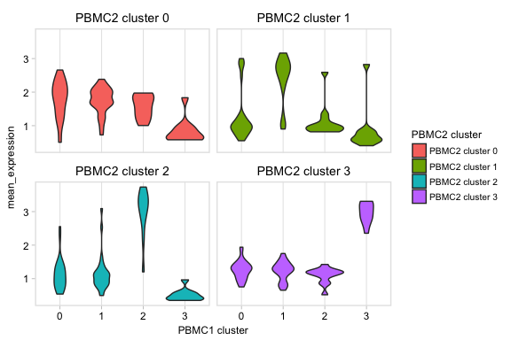

```r
pairwiseVln(pbmc, markers_pbmc, pbmc, sample_names = c("PBMC1", "PBMC2"))
```

## Heatmaps of marker overlap

We may be interested in shared markers between clusters in two samples. When calculating this value, we can use as the denominator of the equation either the number of markers in sample 1 or the number of markers in sample 2. This function provides a few options for what to plot in the heatmap, in the `mode` argument:

- “s1”: Plot the percentage of sample 1 markers which are also markers in sample 2
- “s2”: Plot the percentage of sample 2 markers which are also markers in sample 1
- “min”: Plot the minimum of the above percentages
- “max”: Plot the maximum of the above percentages
- “both”: Plot two heatmaps, one with the percentage of sample 1 markers which are also markers in sample 2, and one the percentage of sample 2 markers which are also markers in sample 1

By default, the function plots the minimum (here, comparing one dataset to itself):

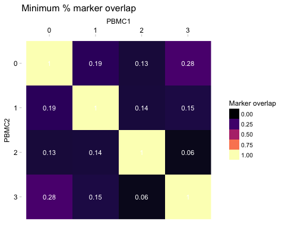

```r
heatmapPercentMarkerOverlap(markers_pbmc, markers_pbmc,
                            sample_names = c("PBMC1", "PBMC2"),
                            # The default for this argument is set to the column name
                            # of output of our pipeline, which is 'external_gene_name'
                            marker_col = "gene")
```

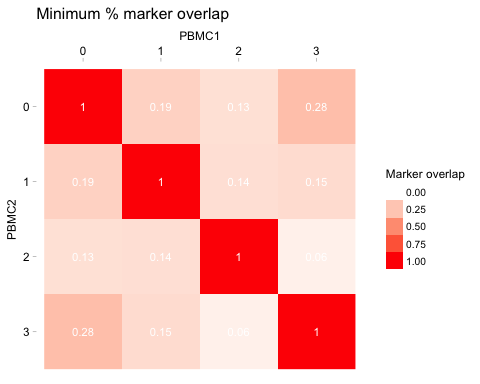

```r
# Change the palette: give a set of colours to interpolate, from low to high
heatmapPercentMarkerOverlap(markers_pbmc, markers_pbmc,
                            sample_names = c("PBMC1", "PBMC2"),
                            marker_col = "gene",
                            palette = c("white", "red"))
```

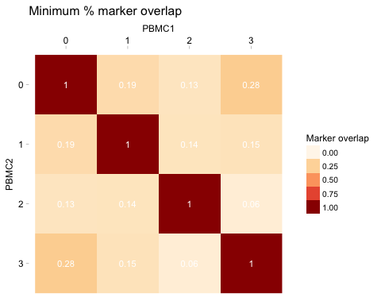

```r
# You can use RColorBrewer palettes like this
heatmapPercentMarkerOverlap(markers_pbmc, markers_pbmc,
                            sample_names = c("PBMC1", "PBMC2"),
                            marker_col = "gene",
                            palette = RColorBrewer::brewer.pal(8, "OrRd"))
```

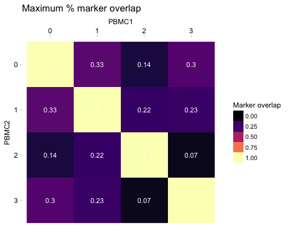

```r
# Plot the max instead
heatmapPercentMarkerOverlap(markers_pbmc, markers_pbmc, mode = "max",
                            sample_names = c("PBMC1", "PBMC2"),
                            marker_col = "gene")
```

Plot both:

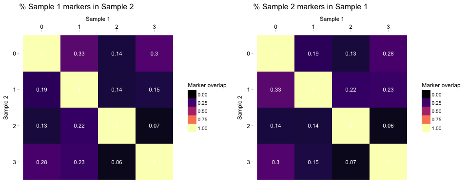

```r
heatmapPercentMarkerOverlap(markers_pbmc, markers_pbmc, marker_col = "gene", mode = "both")
```

# Utilities

Subset data by gene and cluster:

```r
head(fetchData(pbmc, "IL32", c(1, 2)))
```

```
#>   IL32
#> 1    0
#> 2    0
#> 3    0
#> 4    0
#> 5    0
#> 6    0
```

```r
head(fetchData(pbmc, c("IL32", "MS4A1"), c(1, 2), return_cluster = TRUE, return_cell = TRUE))
```

```
#>             Cell Cluster    MS4A1 IL32
#> 1 TACGCCACTCCGAA       1 5.313305    0
#> 2 CTAAACCTGTGCAT       1 5.190573    0
#> 3 CATCATACGGAGCA       1 5.537982    0
#> 4 TTACCATGAATCGC       1 0.000000    0
#> 5 ATAGGAGAAACAGA       1 0.000000    0
#> 6 GCGCACGACTTTAC       1 0.000000    0
```

`cytokit` tells you if you try to plot genes which are undetected in the data:

```r
tsneByMeanMarkerExpression(pbmc, c("MS4A1", "foo"))
```

```
#> [1] "NOTE: [foo] undetected in pbmc"
```

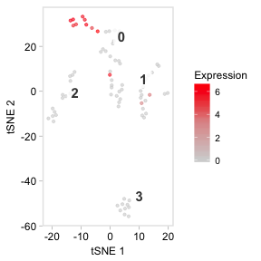